# Test a Perceptual Phenomenon

### Analyzing the Stroop Effect

Perform the analysis in the space below. Remember to follow [the instructions](https://docs.google.com/document/d/1-OkpZLjG_kX9J6LIQ5IltsqMzVWjh36QpnP2RYpVdPU/pub?embedded=True) and review the [project rubric](https://review.udacity.com/#!/rubrics/71/view) before submitting. Once you've completed the analysis and write up, download this file as a PDF or HTML file and submit in the next section.

(1) What is the independent variable? What is the dependent variable?

*INDEPENDENT VARIABLE:* Congruency *DEPENDENT VARIABLE:* Time Taken

(2) What is an appropriate set of hypotheses for this task? What kind of statistical test do you expect to perform? Justify your choices.

H0 - Null Hypothesis: No large difference in the population average response time in viewing the congruent(c) words vs viewing the incongruent(i) words is observed.

H1 - Alternative Hypothesis: Large difference in the population average response time in viewing the congruent(c) words vs viewing the incongruent(i) words is observed.

(3) Report some descriptive statistics regarding this dataset. Include at least one measure of central tendency and at least one measure of variability. The name of the data file is 'stroopdata.csv'.

```python
# Perform the analysis here
import pandas
df = pandas.read_csv('stroopdata.csv')
df.head()
```

|  | Congruent | Incongruent |
| --- | --- | --- |
| 0 | 12.079 | 19.278 |
| 1 | 16.791 | 18.741 |
| 2 | 9.564 | 21.214 |
| 3 | 8.630 | 15.687 |
| 4 | 14.669 | 22.803 |

```python
df['Congruent'].mean()
```

```
14.051124999999999
```

```python
df['Incongruent'].mean()
```

```
22.015916666666666
```

```python
df['Congruent'].median()
```

```
14.3565
```

```python
df['Incongruent'].median()
```

```
21.0175
```

```python
df['Congruent'].std()
```

```
3.5593579576451955
```

```python
df['Incongruent'].std()
```

```
4.7970571224691376
```

(4) Provide one or two visualizations that show the distribution of the sample data. Write one or two sentences noting what you observe about the plot or plots.

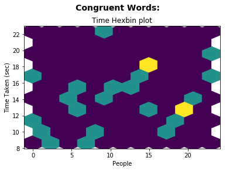

```python
# Build the visualizations hereimport numpy as np
import matplotlib.pyplot as plt
import numpy as np
%matplotlib inline

N = len(df)
x = df.index
y = df['Congruent']

fig = plt.figure()
fig.suptitle('Congruent Words: ', fontsize=14, fontweight='bold')
ax = fig.add_subplot(111)
fig.subplots_adjust(top=0.85)
ax.set_title('Time Hexbin plot')
ax.set_xlabel('People')
ax.set_ylabel('Time Taken (sec)')

plt.hexbin(x, y, gridsize=10)
plt.show()
```

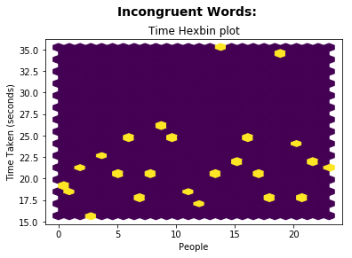

```python
x = df.index
y = df['Incongruent']

fig = plt.figure()
fig.suptitle('Incongruent Words: ', fontsize=14, fontweight='bold')
ax = fig.add_subplot(111)
fig.subplots_adjust(top=0.85)
ax.set_title('Time Hexbin plot')
ax.set_xlabel('People')
ax.set_ylabel('Time Taken (seconds)')

plt.hexbin(x, y, gridsize=25)
plt.show()
```

*The congruent column has ranged from 8 - 22 seconds, whereas incongruent column has ranged from 16 - 26 seconds. Incongruent data has two outliers at 33 and 35 seconds. Therefore it is evident from the ranges that Incongruency has taken more time.*

(5) Now, perform the statistical test and report the results. What is the confidence level and your critical statistic value? Do you reject the null hypothesis or fail to reject it? Come to a conclusion in terms of the experiment task. Did the results match up with your expectations?

```python
# Perform the statistical test here
n = len(df)
n
```

```
24
```

```python
PE = df['Incongruent'].mean()- df['Congruent'].mean()
PE
```

```
7.9647916666666667
```

```python
# D = sample difference
df['D'] = df['Incongruent'] - df['Congruent']
df.head()
```

[output not shown]

```python
print (PE/(df['D'].std()/(sqrt(n))))
```

```
8.02070694411
```

Conclusion:

8.0207 > 1.711

*The Null Hypothesis which predicts there is no major difference between the population average time for the two conditions is being REJECTED. In theory, we were able to calculate the average difference of every single person person who took this pair of tests, we expect there would be a significantly slower or significantly faster time in either the the incongruent or congruent condition respectively. The results were just as expected since our own experience showed that the second condition took longer to complete.*